# Rosy Rockfish

*Sebastes rosaceus*

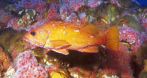

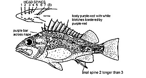

**Body color:** Orange-red to purple w/ yellow wash on lower sides; 4 or 5 clear, whitish blotches, bordered w/ purple-red on upper part of body; fins pink w/ yellow. (See also above underwater photo.)

**Peritoneum color:** gray to dark **Shape between eyes:** concave

**Counts:** D:XIII-XIV,11-14, Ar:5-7, P1:16-18, GR:29-34, LLp:36-46, LLs:?-?, V:26

**Occurence:** Washington (Cobb Seamount) - Baja California

**Depth:** 128 meters **Size:** 36 cm **Species code:** 30460

**Similar species:**

- *Rosethorn rockfish* - body orange-red, white spots bordered by light pink or orange; pectoral rays typically 16 (typically 17 in Rosy RF); caudal peduncle typically thinner,depth less than orbit width (greater than orbit width in Rosy RF)
- *Pinkrose rockfish* - body uniform red; caudal peduncle depth typically less than orbit width (greater than orbit width in Rosy RF)
- *Starry rockfish* - body covered w/ white dots; gillrakers 25-30 (29-34 in Rosy RF)
- *Swordspine rockfish* - lower jaw projecting (jaws equal in Rosy RF); symphyseal knob prominent (absent or small in Rosy RF); gillrakers 34-40 (29-34 in Rosy RF)
- *Greenspotted rockfish* - body orange-red w/ green spots, white spots bordered by light pink or orange; caudal peduncle typically thinner,depth less than orbit width (greater than orbit width in Rosy RF)
- *Pink rockfish and Greenblotched rockfish* - body w/ irregular greenish blotches
- *Freckled rockfish* - prominent knobs bordering notch in upper jaw & dense green freckling on back (absent in Rosy RF); gillrakers 34-39 (29-34 in Rosy RF)

Back to Group

**Corrections:** If you see mistakes or want to suggest changes, please create an [issue](https://github.com/zoyafuso-NOAA/RACE_Survey_App/issues) on the source repository or

*reach out to Liz Dawson (Liz.Dawson AT noaa.gov).*